# Lab 14: Dummys and Categories

Tyler Scott

2015-08-16

** Inspiration for this lab comes from the work of Jonathan Tannen

## Goals for Today

1. Dummy regression.
2. Interactions.
3. Presenting results.

## “UN Data on Life Expectancy.”

- Load the dataset from Fox:
- http://socserv.socsci.mcmaster.ca/jfox/Books/Applied-Regression-2E/dataset/UnitedNations.txt
- More info on dataset: http://socserv.socsci.mcmaster.ca/jfox/Books/Applied-Regression-2E/datasets/UnitedNations.pdf
- Explore the dataset.
- Make some plots of Life Expectancy. Anything interesting?

```r
library(ggplot2)
library(dplyr)
df <-read.table("http://socserv.socsci.mcmaster.ca/jfox/Books/Applied-Regression-2E/datasets/UnitedNations.txt")
df$country <- rownames(df)
rownames(df) <- NULL
df <- tbl_df(df)
df
```

```
## Source: local data frame [207 x 14]
##
##     region   tfr contraception educationMale educationFemale lifeMale
##     (fctr) (dbl)         (int)         (dbl)           (dbl)    (dbl)
## 1     Asia  6.90            NA            NA              NA     45.0
## 2   Europe  2.60            NA            NA              NA     68.0
## 3   Africa  3.81            52          11.1             9.9     67.5
## 4     Asia    NA            NA            NA              NA     68.0
## 5   Europe    NA            NA            NA              NA       NA
## 6   Africa  6.69            NA            NA              NA     44.9
## 7  America    NA            53            NA              NA       NA
## 8  America  2.62            NA            NA              NA     69.6
## 9   Europe  1.70            22            NA              NA     67.2
## 10 Oceania  1.89            76          16.3            16.1     75.4
## ..     ...   ...           ...           ...             ...      ...
## Variables not shown: lifeFemale (dbl), infantMortality (int), GDPperCapita
##   (int), economicActivityMale (dbl), economicActivityFemale (dbl),
##   illiteracyMale (dbl), illiteracyFemale (dbl), country (chr)
```

## Male and Female Life Expectancy

1. Describe the difference between Male and Female Life Expectancy using statistics.

```r
df %>% summarise_each(funs(mean(.,na.rm=T)),lifeMale,lifeFemale)
```

```
## Source: local data frame [1 x 2]
##
##   lifeMale lifeFemale
##      (dbl)      (dbl)
## 1 63.62551   68.39184
```

```r
t.test(df$lifeMale,df$lifeFemale)
```

```
##
##  Welch Two Sample t-test
##
## data:  df$lifeMale and df$lifeFemale
## t = -4.5226, df = 384.46, p-value = 8.148e-06
## alternative hypothesis: true difference in means is not equal to 0
## 95 percent confidence interval:
##  -6.838425 -2.694228
## sample estimates:
## mean of x mean of y
##  63.62551  68.39184
```

2. Describe the difference between Male and Female Life Expectancy visually. (Challenge yourself to keep adding information!)

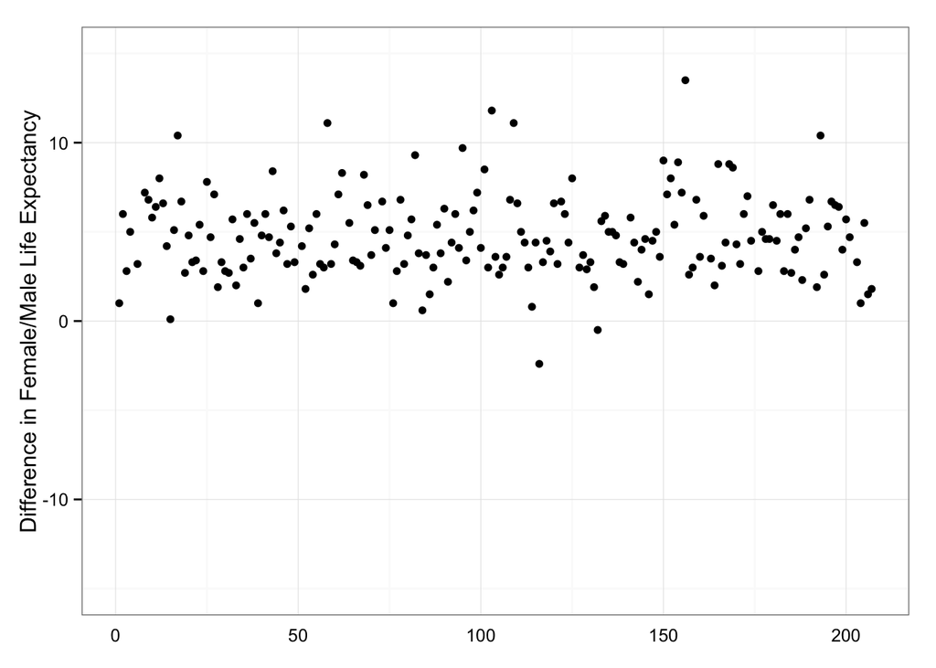

```r
ggplot(data=df,aes(x=1:nrow(df),y=lifeFemale-lifeMale))+  geom_point(show_guide = FALSE) +
  theme_bw() +
  theme(axis.ticks.x=element_blank(),
        axis.title.x=element_blank())+
  scale_y_continuous(name='Difference in Female/Male Life Expectancy',limits=c(-15,15))
```

3. Describe the difference between Male and Female Life Expectancy by region using statistics. (What kind of variable is ‘region’?)

```r
df %>% group_by(region) %>%
  summarise(Avg.Regional.Difference = mean(lifeFemale-lifeMale,na.rm=T))
```

```
## Source: local data frame [5 x 2]
##
##    region Avg.Regional.Difference
##    (fctr)                   (dbl)
## 1  Africa                3.235185
## 2 America                5.391429
## 3    Asia                4.038000
## 4  Europe                7.142857
## 5 Oceania                4.593333
```

4. Add region information to your plot.

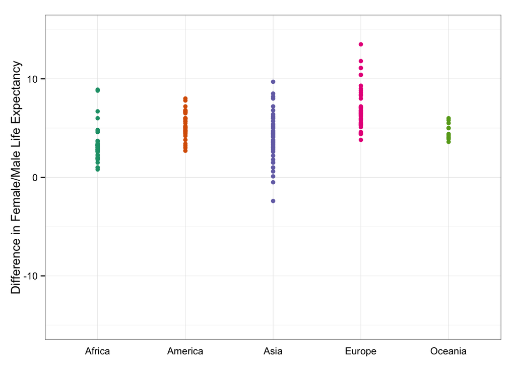

```r
ggplot(data=df,aes(x=region,label=region,y=lifeFemale-lifeMale,colour=region))+  geom_point(show_guide = FALSE) +
  theme_bw() +
  theme(axis.ticks.x=element_blank(),
        axis.title.x=element_blank())+
  scale_y_continuous(name='Difference in Female/Male Life Expectancy',limits=c(-15,15)) +
  scale_colour_brewer(name='Region',type='qual',palette=2)
```

5. Challenge: Redo the plot, but try adding the country names instead of points.

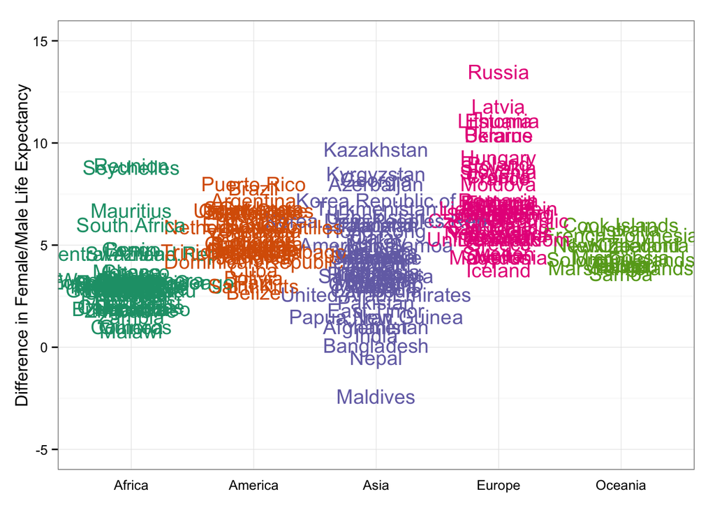

```r
ggplot(data=df,aes(x=region,label=country,y=lifeFemale-lifeMale,colour=region))+  geom_text(show_guide = FALSE) +
  theme_bw() +
  theme(axis.ticks.x=element_blank(),
        axis.title.x=element_blank())+
  scale_y_continuous(name='Difference in Female/Male Life Expectancy',limits=c(-5,15)) +
  scale_colour_brewer(name='Region',type='qual',palette=2)
```

## Comparing Regions

1. Create a dummy for European countries.

```r
df$Europe = ifelse(df$region=='Europe',1,0)
```

2. Create a dummy for non-European countries.

```r
df$Not.Europe = ifelse(df$region=='Europe',0,1)
```

3. Regress female life expectancy on the europe dummy. Regress female life expectancy on the non-europe dummy. What do you notice?

```r
summary(lm(lifeFemale~Europe,data=df))
```

```
##
## Call:
## lm(formula = lifeFemale ~ Europe, data = df)
##
## Residuals:
##     Min      1Q  Median      3Q     Max
## -26.816  -6.316   2.357   7.409  16.984
##
## Coefficients:
##             Estimate Std. Error t value Pr(>|t|)
## (Intercept)  65.9156     0.8051  81.872   <2e-16 ***
## Europe       11.5558     1.7392   6.644    3e-10 ***
## ---
## Signif. codes:  0 '***' 0.001 '**' 0.01 '*' 0.05 '.' 0.1 ' ' 1
##
## Residual standard error: 9.991 on 194 degrees of freedom
##   (11 observations deleted due to missingness)
## Multiple R-squared:  0.1854, Adjusted R-squared:  0.1812
## F-statistic: 44.15 on 1 and 194 DF,  p-value: 3e-10
```

```r
summary(lm(lifeFemale~Not.Europe,data=df))
```

```
##
## Call:
## lm(formula = lifeFemale ~ Not.Europe, data = df)
##
## Residuals:
##     Min      1Q  Median      3Q     Max
## -26.816  -6.316   2.357   7.409  16.984
##
## Coefficients:
##             Estimate Std. Error t value Pr(>|t|)
## (Intercept)   77.471      1.542  50.252   <2e-16 ***
## Not.Europe   -11.556      1.739  -6.644    3e-10 ***
## ---
## Signif. codes:  0 '***' 0.001 '**' 0.01 '*' 0.05 '.' 0.1 ' ' 1
##
## Residual standard error: 9.991 on 194 degrees of freedom
##   (11 observations deleted due to missingness)
## Multiple R-squared:  0.1854, Adjusted R-squared:  0.1812
## F-statistic: 44.15 on 1 and 194 DF,  p-value: 3e-10
```

4. Regress female life expectancy on ‘region’. Interpret the results.

```r
summary(lm(lifeFemale~region,data=df))
```

```
##
## Call:
## lm(formula = lifeFemale ~ region, data = df)
##
## Residuals:
##      Min       1Q   Median       3Q      Max
## -23.3000  -3.6229   0.7643   3.7529  24.3685
##
## Coefficients:
##               Estimate Std. Error t value Pr(>|t|)
## (Intercept)    55.4315     0.9679  57.273  < 2e-16 ***
## regionAmerica  19.0428     1.5434  12.338  < 2e-16 ***
## regionAsia     13.8685     1.3959   9.936  < 2e-16 ***
## regionEurope   22.0399     1.4633  15.062  < 2e-16 ***
## regionOceania  16.9752     2.0758   8.178 3.95e-14 ***
## ---
## Signif. codes:  0 '***' 0.001 '**' 0.01 '*' 0.05 '.' 0.1 ' ' 1
##
## Residual standard error: 7.112 on 191 degrees of freedom
##   (11 observations deleted due to missingness)
## Multiple R-squared:  0.5936, Adjusted R-squared:  0.5851
## F-statistic: 69.74 on 4 and 191 DF,  p-value: < 2.2e-16
```

## Life Expectancy and GDP

1. Plot female life expectancy and female education (with region colors).

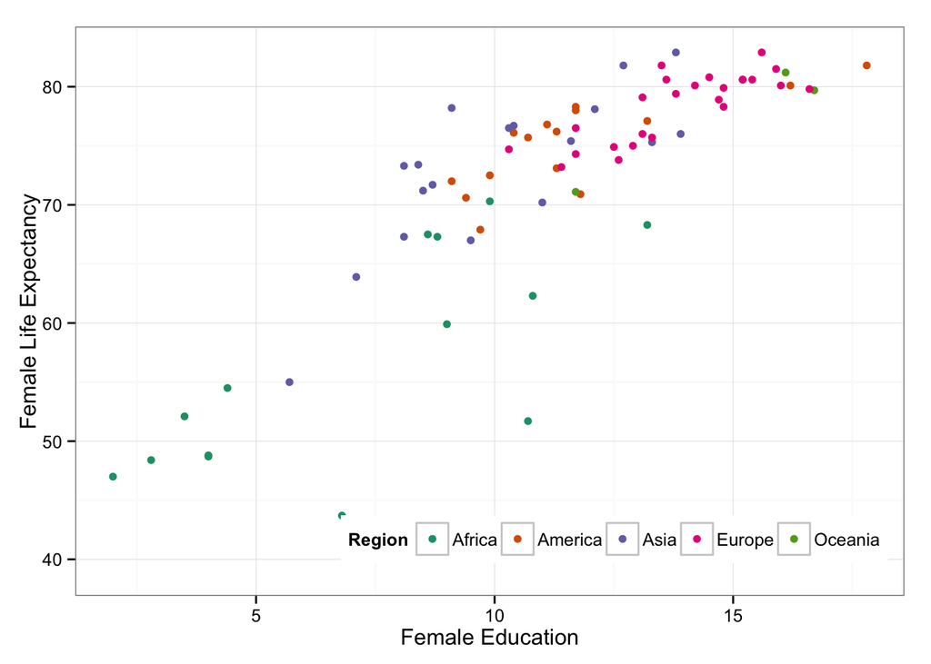

```r
ggplot(df,aes(x=educationFemale,y=lifeFemale,colour=region)) +
  geom_point() + theme_bw() +
  theme(legend.position = c(0.65,0.1),
        legend.direction='horizontal') +
  scale_colour_brewer(name='Region',palette=2,type='qual')+
  scale_y_continuous('Female Life Expectancy')+
  scale_x_continuous('Female Education')
```

2. Regress female life expectancy on female education. Interpret the results. Plot the regression line.

```r
mod1 = lm(lifeFemale~educationFemale,data=df)
summary(mod1)
```

```
##
## Call:
## lm(formula = lifeFemale ~ educationFemale, data = df)
##
## Residuals:
##      Min       1Q   Median       3Q      Max
## -27.4924  -2.0819   0.3311   3.9882  11.5267
##
## Coefficients:
##                 Estimate Std. Error t value Pr(>|t|)
## (Intercept)      44.8440     2.3715   18.91   <2e-16 ***
## educationFemale   2.3988     0.2011   11.93   <2e-16 ***
## ---
## Signif. codes:  0 '***' 0.001 '**' 0.01 '*' 0.05 '.' 0.1 ' ' 1
##
## Residual standard error: 6.053 on 74 degrees of freedom
##   (131 observations deleted due to missingness)
## Multiple R-squared:  0.6578, Adjusted R-squared:  0.6532
## F-statistic: 142.3 on 1 and 74 DF,  p-value: < 2.2e-16
```

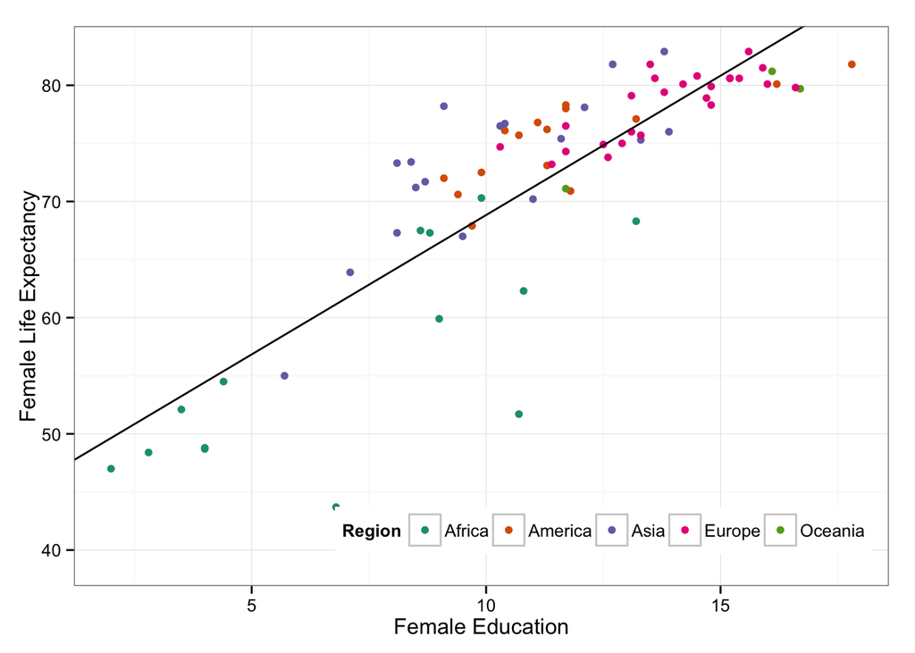

```r
ggplot(df,aes(x=educationFemale,y=lifeFemale,colour=region)) +
  geom_point() + theme_bw() +
  theme(legend.position = c(0.65,0.1),legend.direction='horizontal') +
 scale_colour_brewer(name='Region',palette=2,type='qual')+
  scale_y_continuous('Female Life Expectancy')+
  scale_x_continuous('Female Education') +
   geom_abline(aes(intercept=coef(mod1)[1],slope=coef(mod1)[2]))
```

3. Regress female life expectancy on female education and the Europe dummy. Interpret each. Plot the regression lines.

```r
mod2 = lm(lifeFemale~educationFemale+Europe,data=df)
summary(mod2)
```

```
##
## Call:
## lm(formula = lifeFemale ~ educationFemale + Europe, data = df)
##
## Residuals:
##      Min       1Q   Median       3Q      Max
## -27.3588  -1.8793   0.1685   4.0997  11.6273
##
## Coefficients:
##                 Estimate Std. Error t value Pr(>|t|)
## (Intercept)      45.1183     2.5253  17.867  < 2e-16 ***
## educationFemale   2.3576     0.2375   9.928 3.46e-15 ***
## Europe            0.5785     1.7448   0.332    0.741
## ---
## Signif. codes:  0 '***' 0.001 '**' 0.01 '*' 0.05 '.' 0.1 ' ' 1
##
## Residual standard error: 6.089 on 73 degrees of freedom
##   (131 observations deleted due to missingness)
## Multiple R-squared:  0.6584, Adjusted R-squared:  0.649
## F-statistic: 70.34 on 2 and 73 DF,  p-value: < 2.2e-16
```

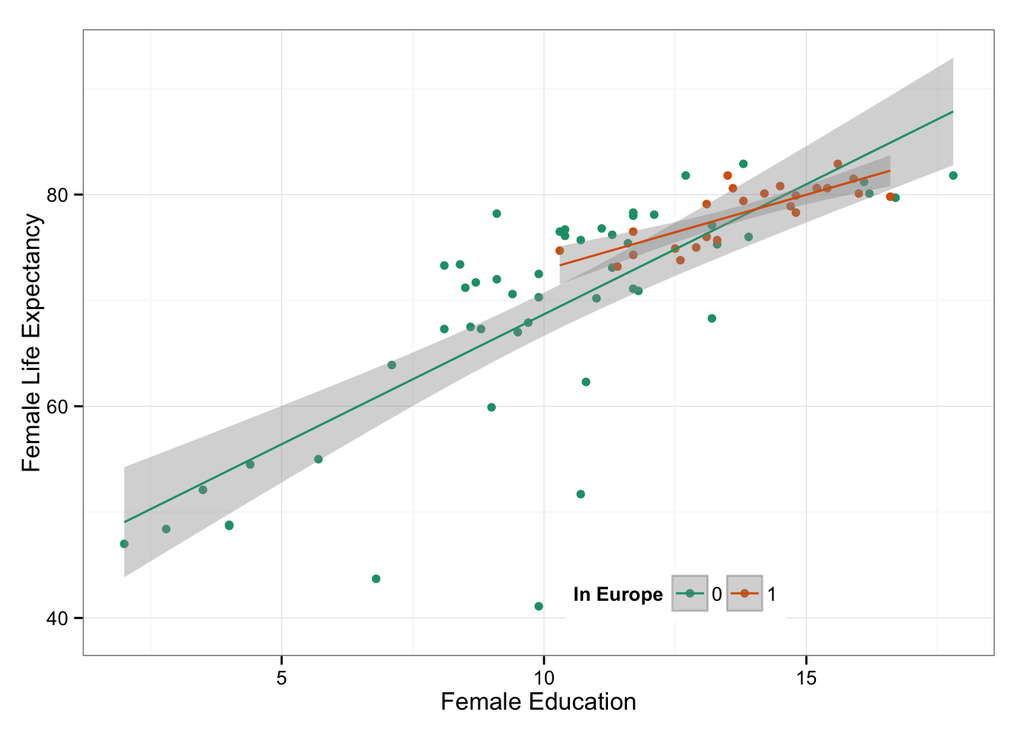

```r
ggplot(df,aes(x=educationFemale,y=lifeFemale,colour=as.factor(Europe))) +
  geom_point() + theme_bw() +
  theme(legend.position = c(0.65,0.1),legend.direction='horizontal') +
 scale_colour_brewer(name='In Europe',palette=2,type='qual')+
  scale_y_continuous('Female Life Expectancy')+
  scale_x_continuous('Female Education') +
  geom_smooth(method='lm')
```

4. Regress female life expectancy on female education, only for European countries. Plot the regression line.

```r
mod3 = lm(lifeFemale~educationFemale,data=df[df$Europe==1,])
summary(mod3)
```

```
##
## Call:
## lm(formula = lifeFemale ~ educationFemale, data = df[df$Europe ==
##     1, ])
##
## Residuals:
##     Min      1Q  Median      3Q     Max
## -2.7814 -1.4038  0.1962  1.2478  3.9413
##
## Coefficients:
##                 Estimate Std. Error t value Pr(>|t|)
## (Intercept)      58.6988     3.1230  18.796 1.86e-15 ***
## educationFemale   1.4193     0.2239   6.338 1.82e-06 ***
## ---
## Signif. codes:  0 '***' 0.001 '**' 0.01 '*' 0.05 '.' 0.1 ' ' 1
##
## Residual standard error: 1.768 on 23 degrees of freedom
##   (19 observations deleted due to missingness)
## Multiple R-squared:  0.6359, Adjusted R-squared:   0.62
## F-statistic: 40.17 on 1 and 23 DF,  p-value: 1.818e-06
```

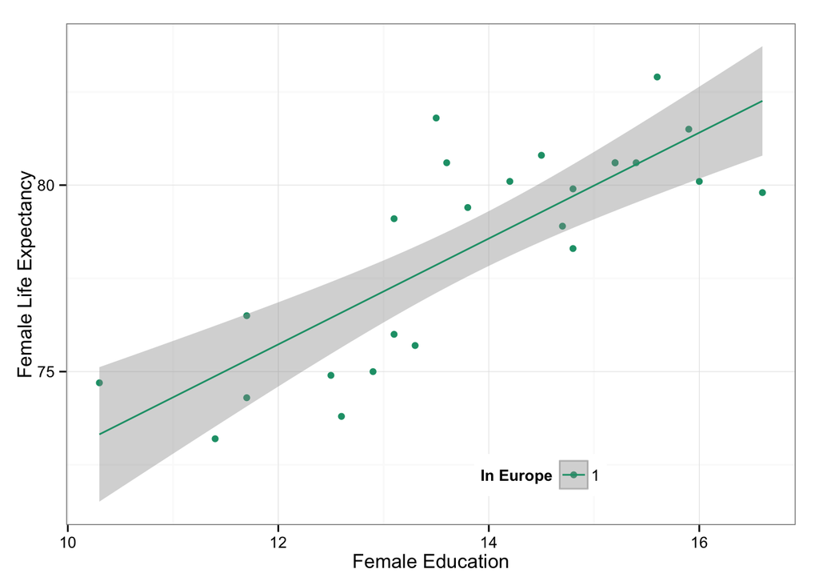

```r
ggplot(df[df$Europe==1,],aes(x=educationFemale,y=lifeFemale,colour=as.factor(Europe))) +
  geom_point() + theme_bw() +
  theme(legend.position = c(0.65,0.1),legend.direction='horizontal') +
 scale_colour_brewer(name='In Europe',palette=2,type='qual')+
  scale_y_continuous('Female Life Expectancy')+
  scale_x_continuous('Female Education') +
  geom_smooth(method='lm')
```

5. Regress female life expectancy on female education, only for American countries. Plot the regression line.

```r
mod4 = lm(lifeFemale~educationFemale,data=df[df$region=='America',])
summary(mod4)
```

```
##
## Call:
## lm(formula = lifeFemale ~ educationFemale, data = df[df$region ==
##     "America", ])
##
## Residuals:
##     Min      1Q  Median      3Q     Max
## -4.8069 -1.1967  0.0279  2.0734  3.1437
##
## Coefficients:
##                 Estimate Std. Error t value Pr(>|t|)
## (Intercept)      60.8273     3.3485  18.166 1.27e-10 ***
## educationFemale   1.2247     0.2809   4.359 0.000773 ***
## ---
## Signif. codes:  0 '***' 0.001 '**' 0.01 '*' 0.05 '.' 0.1 ' ' 1
##
## Residual standard error: 2.55 on 13 degrees of freedom
##   (26 observations deleted due to missingness)
## Multiple R-squared:  0.5938, Adjusted R-squared:  0.5626
## F-statistic:    19 on 1 and 13 DF,  p-value: 0.0007734
```

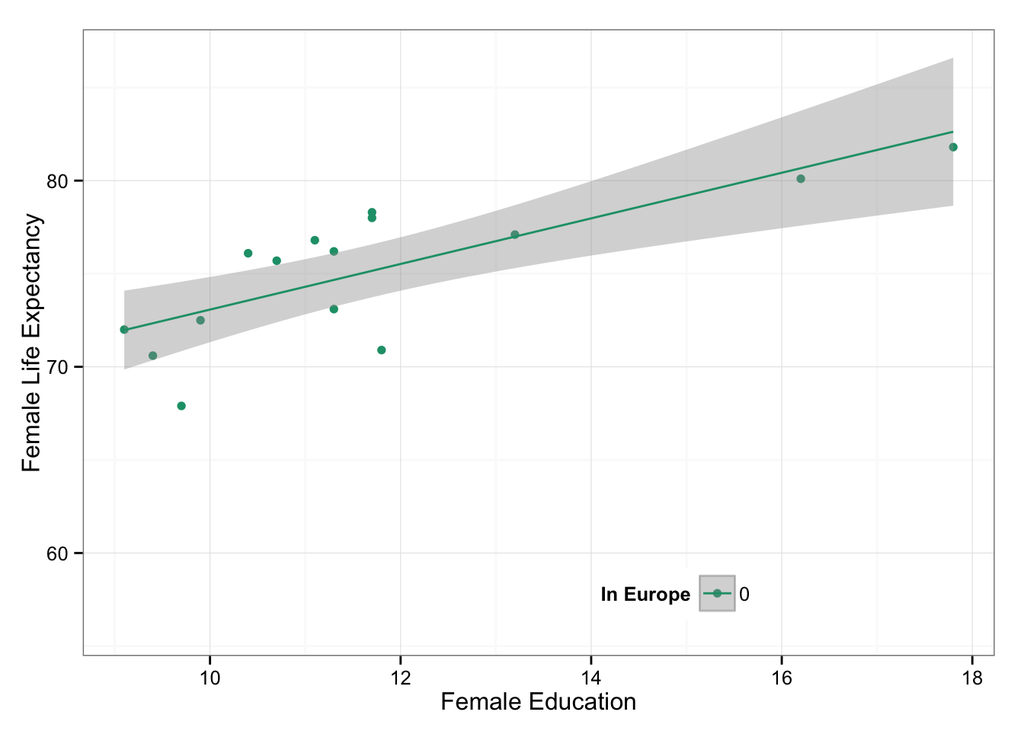

```r
ggplot(df[df$region=='America',],aes(x=educationFemale,y=lifeFemale,colour=as.factor(Europe))) +
  geom_point() + theme_bw() +
  theme(legend.position = c(0.65,0.1),legend.direction='horizontal') +
 scale_colour_brewer(name='In Europe',palette=2,type='qual')+
  scale_y_continuous('Female Life Expectancy')+
  scale_x_continuous('Female Education') +
  geom_smooth(method='lm')
```

6. Regress female life expectancy on female education, Europe, and the interaction between the two. Plot the regression lines.

```r
mod5 = lm(lifeFemale~educationFemale + Europe + educationFemale:Europe,data=df)
summary(mod5)
```

```
##
## Call:
## lm(formula = lifeFemale ~ educationFemale + Europe + educationFemale:Europe,
##     data = df)
##
## Residuals:
##      Min       1Q   Median       3Q      Max
## -27.3480  -2.0171   0.2818   3.5203  11.7167
##
## Coefficients:
##                        Estimate Std. Error t value Pr(>|t|)
## (Intercept)             44.1349     2.6282  16.793  < 2e-16 ***
## educationFemale          2.4559     0.2485   9.883 4.84e-15 ***
## Europe                  14.5638    11.0272   1.321    0.191
## educationFemale:Europe  -1.0366     0.8071  -1.284    0.203
## ---
## Signif. codes:  0 '***' 0.001 '**' 0.01 '*' 0.05 '.' 0.1 ' ' 1
##
## Residual standard error: 6.062 on 72 degrees of freedom
##   (131 observations deleted due to missingness)
## Multiple R-squared:  0.666,  Adjusted R-squared:  0.6521
## F-statistic: 47.86 on 3 and 72 DF,  p-value: < 2.2e-16
```

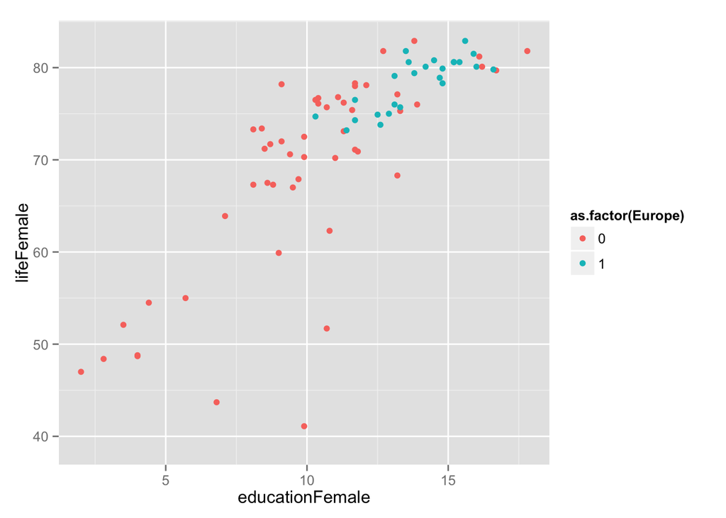

```r
ggplot(df,aes(x=educationFemale,y=lifeFemale,colour=as.factor(Europe))) +
  geom_point()
```

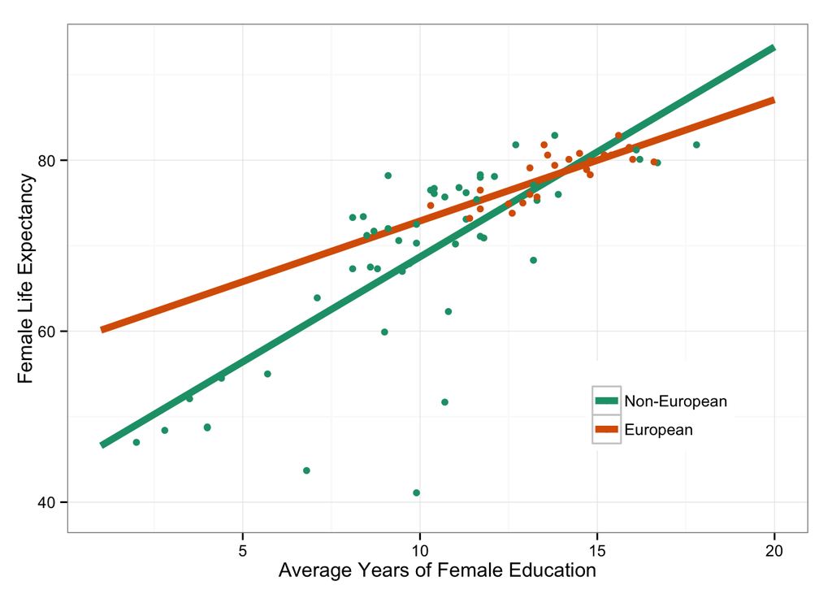

```r
base.ed = coef(mod5)[1] + coef(mod5)[2]*(1:20)
europe.ed = coef(mod5)[1] + coef(mod5)[2]*(1:20) + coef(mod5)[3] * 1 + coef(mod5)[4] * 1 * (1:20)

ests = data.frame(y.hat = c(base.ed,europe.ed),Europe = rep(c(0,1),each=20),Education = rep(1:20,2))

ggplot()  + geom_line(aes(x=Education,y=y.hat,colour=as.factor(Europe),group=Europe),size=2,data=ests) +
  theme_bw() + theme(legend.position = c(0.8,0.25)) +
  scale_colour_brewer(name='',label=c('Non-European','European'),type='qual',palette=2) +
  geom_point(data=df,aes(x=educationFemale,y=lifeFemale,colour=as.factor(Europe))) +
  ylab('Female Life Expectancy') + xlab('Average Years of Female Education')
```

## Life Expectancy and GDP

```r
mod6 = lm(lifeFemale~region,data=df)
summary(mod6)
```

```
##
## Call:
## lm(formula = lifeFemale ~ region, data = df)
##
## Residuals:
##      Min       1Q   Median       3Q      Max
## -23.3000  -3.6229   0.7643   3.7529  24.3685
##
## Coefficients:
##               Estimate Std. Error t value Pr(>|t|)
## (Intercept)    55.4315     0.9679  57.273  < 2e-16 ***
## regionAmerica  19.0428     1.5434  12.338  < 2e-16 ***
## regionAsia     13.8685     1.3959   9.936  < 2e-16 ***
## regionEurope   22.0399     1.4633  15.062  < 2e-16 ***
## regionOceania  16.9752     2.0758   8.178 3.95e-14 ***
## ---
## Signif. codes:  0 '***' 0.001 '**' 0.01 '*' 0.05 '.' 0.1 ' ' 1
##
## Residual standard error: 7.112 on 191 degrees of freedom
##   (11 observations deleted due to missingness)
## Multiple R-squared:  0.5936, Adjusted R-squared:  0.5851
## F-statistic: 69.74 on 4 and 191 DF,  p-value: < 2.2e-16
```

In this case, Africa is the reference category. Thus, the model predicts that relative to Africa a country in the Americas is predicted to have 19.04 years greater female life expectancy.

- Regress female life expectancy on every region dummy interacted with female education. Interpret every term.

```r
mod7 = lm(lifeFemale ~ region*educationFemale,data=df)
summary(mod7)
```

```
##
## Call:
## lm(formula = lifeFemale ~ region * educationFemale, data = df)
##
## Residuals:
##      Min       1Q   Median       3Q      Max
## -18.5560  -1.5552   0.1514   1.9778  10.6440
##
## Coefficients:
##                               Estimate Std. Error t value Pr(>|t|)
## (Intercept)                    44.0432     2.7581  15.969  < 2e-16 ***
## regionAmerica                  16.7840     6.5615   2.558   0.0128 *
## regionAsia                      7.0107     5.5123   1.272   0.2079
## regionEurope                   14.6555     8.4703   1.730   0.0883 .
## regionOceania                   4.5853    17.8279   0.257   0.7978
## educationFemale                 1.5770     0.3456   4.564 2.25e-05 ***
## regionAmerica:educationFemale  -0.3523     0.6074  -0.580   0.5638
## regionAsia:educationFemale      0.5893     0.5748   1.025   0.3090
## regionEurope:educationFemale   -0.1578     0.6702  -0.235   0.8146
## regionOceania:educationFemale   0.3581     1.2240   0.293   0.7708
## ---
## Signif. codes:  0 '***' 0.001 '**' 0.01 '*' 0.05 '.' 0.1 ' ' 1
##
## Residual standard error: 4.534 on 66 degrees of freedom
##   (131 observations deleted due to missingness)
## Multiple R-squared:  0.8288, Adjusted R-squared:  0.8054
## F-statistic:  35.5 on 9 and 66 DF,  p-value: < 2.2e-16
```

- Put this information on your scatter plot. (Think hard about the most intuitive way to present it!)

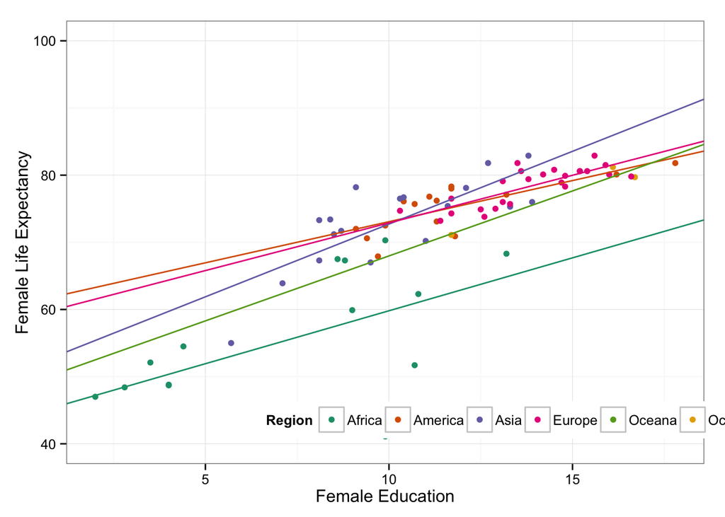

```r
coef.df = data.frame(Region.Intercept = c(coef(mod7)[1],coef(mod7)[1]+coef(mod7)[2:5]),
                     Region.Slope = c(coef(mod7)[6],coef(mod7)[6]+coef(mod7)[7:10]),
                     Region = c('Africa','America','Asia','Europe','Oceana'))

ggplot() + geom_point(data=df,aes(y=lifeFemale,x=educationFemale,colour=region)) +
  geom_abline(aes(intercept=Region.Intercept,slope=Region.Slope,colour=Region),data=coef.df) +
  theme_bw() + theme(legend.position=c(0.7,0.1),legend.direction='horizontal') +
  scale_colour_brewer('Region',palette=2,type='qual') +
  ylab('Female Life Expectancy') +
  xlab('Female Education')+ scale_y_continuous(limits=c(40,100))
```

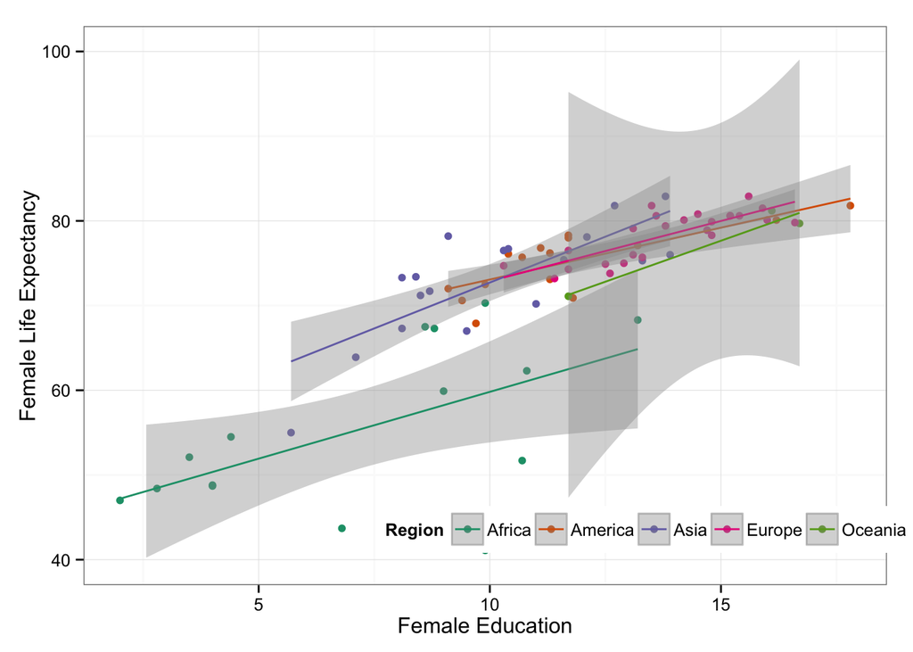

```r
ggplot(df,aes(y=lifeFemale,x=educationFemale,colour=region)) + geom_point() + geom_smooth(aes(group=region),method='lm') +
  theme_bw() + theme(legend.position=c(0.7,0.1),legend.direction='horizontal') +
  scale_colour_brewer('Region',palette=2,type='qual') +
  ylab('Female Life Expectancy') +
  xlab('Female Education') + scale_y_continuous(limits=c(40,100))
```